# Spatial Data Ch 01-02

last updated: 2022-04-26

## Spatial Data in R

[figure not shown]

## Spatial Data in R

- Ch 01:
  - Overview
  - The datasets
- Ch 02
  - R tricks
  - Problems

## Sensors and satellites

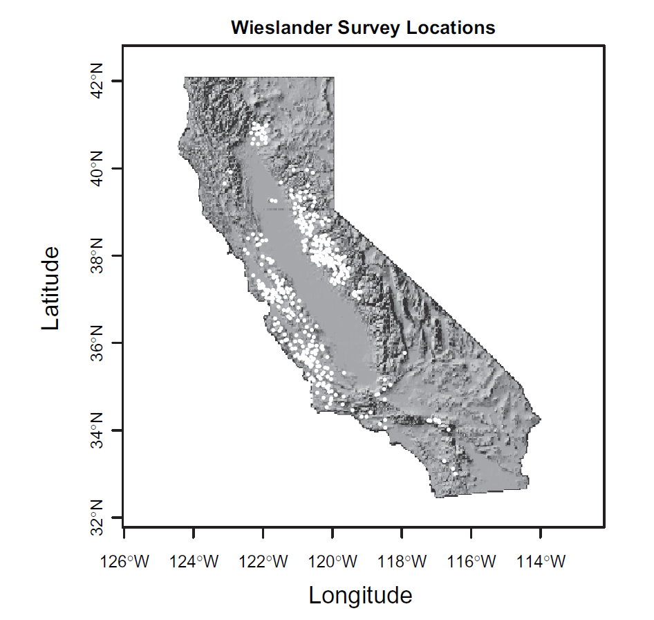

## Sensors and satellites

- Increase in sensors, increase in available data
- Statistical methods and software
- So-called `spatial data`
- subtleties, but basically geolocated, x and y coordinates
- CRS (Coordinate Reference System[s])

## Special problems in spatial data

Statistical properties

1. Spatial data has a lot of data points, so `power` is large even for `tiny effect sizes`, thus the Null is always rejected (even if practically meaningless)
2. Spatial data points near each other are almost never `independent`, violating the common assumption that they are (a/k/a `spatial autocorrelation`)

## Special problems in spatial data

Ecological properties

- Low ‘ecological resolution’
- High ‘data resolution’
- Complex relationships

(next slide shows **Soil moisture**, **Veg reflectance**, **Yield**…)

## Special problems in spatial data

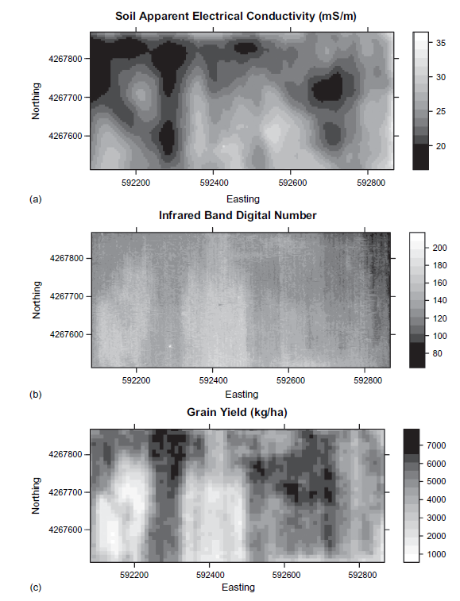

## Cressie’s classification

1. **Geostatistical data** x-y point data with a continuous measure (like soil moisture). Extrapolation between measured points is a goal.
2. **Areal data** points or polygons representing a uniform unit of measure (like the crop planted within a field boundary)
3. **Point pattern data** what is the spatial pattern (like whether pest outbreaks are random or spatially explained by some feature)

## Geostatistical versus Areal

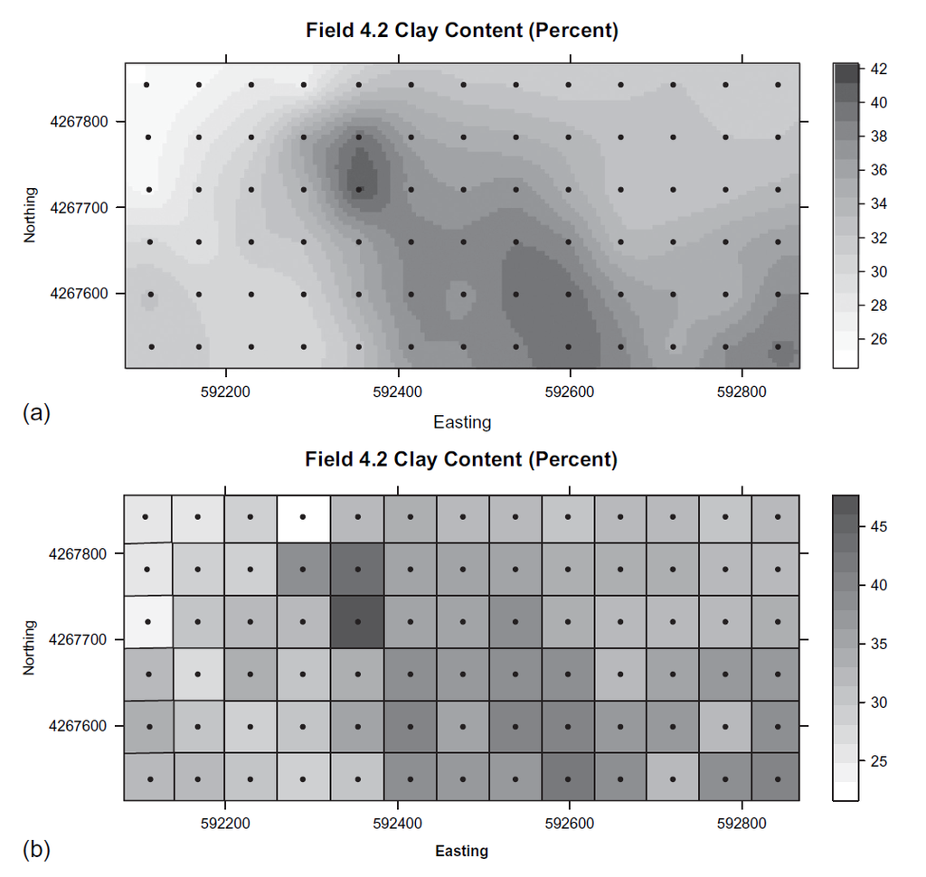

## Components of spatial data

1. Spatial component (x-y)
2. Attribute component (something measured or classified)
3. Scale and sample size (for measuring earthworms, is 1m or 1000m better to sample?)
4. **Vectore data** versus **Raster data**

## Datasets

Ex: dataset 1 yellow billed cuckoo habitat

What spatial featured are associated with presence in this species?

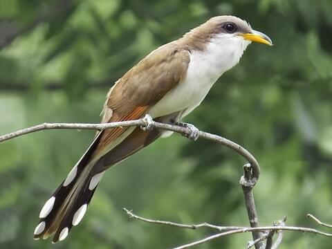

## Datasets

Ex: dataset 1 yellow billed cuckoo habitat

What spatial featured are associated with presence in this species?

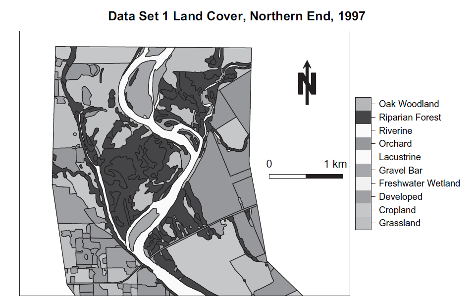